# ETC 1010 Assignment 4

Di Cook

# Instructions

- This is a team assignment, of between 2-4 people. You can work with the same team from the previous assignments, or you can create a new team.
- You need to write a report that
  - answers the questions. Using paragraphs and full sentences, to respond to each question.
  - provides a choice of good plots to support your answers
  - has a good summary of what you have learned about precipitation patterns across Australia
- Turn in `html` output file, and also the `Rmd` file, and a file documenting the team name, team members and %effort by each.
- Use your team name on the report
- Total points for the assignment is 20. Five points of the score from the assignment will be given by other class members, who will give you full marks if they can compile your report, and get the same answers as you, and find your summaries, explanations and justifications understandable and informative.

# Exercise

*I love a sunburnt country*

*A land of sweeping plains*

*Of ragged mountain ranges*

*Of droughts and flooding rains*

(From the poem My Country by Dorothea MxKellar)

How is the climate changing across Australia, particularly rainfall? Read the article on the [Bureau of Meteorology web site on rainfall patterns across Australia](http://www.bom.gov.au/climate/updates/articles/a010-southern-rainfall-decline.shtml).

This assignment is about examining and modeling precipitation records from 239 weather stations across Australia. The data was downloaded, cleaned and processed using the code below. **You don’t need to do any more data collection yourself.**

```r
library(tidyverse)
stns <- read_fwf("https://www1.ncdc.noaa.gov/pub/data/ghcn/daily/ghcnd-stations.txt",
   fwf_widths(c(11, 9, 10, 7, 3, 30, 4, 4, 6),
   c("stn", "lat", "lon", "elev", "state", "name", "flg1", "flg2", "wmo")))
stns_oz <- stns[grep("ASN", stns$stn),]
keep <- stns_oz %>%
  filter(lat > -43, lat < -12, lon > 113.6, lon < 153.6)
smpl <- stns_oz$stn[sample(1:nrow(keep), 1000)]
# The R package rnoaa can also be used to pull the data
oz_weather <- NULL
for (i in 1:length(smpl)) {
  cat(i, "\n")
  filenm <- paste0("https://www1.ncdc.noaa.gov/pub/data/ghcn/daily/all/",
                   smpl[i],".dly")
   x <- read_fwf(filenm,
   col_positions=fwf_widths(c(11, 4, 2, 4,
        rep(c(5, 1, 1, 1), 31)),
        col_names = c("station", "year", "month",
              "variable", paste0("X", 5:128))))
   oz_weather <- bind_rows(oz_weather, x)
}
oz_weather <- oz_weather %>% filter(variable == "PRCP")
oz_weather <- oz_weather[,c(1:4, seq(5,128,4))]
oz_weather_long <- oz_weather %>%
  gather(day, value, X5:X125)
oz_weather_long <- oz_weather_long %>%
  mutate(day = sub("X", "", day)) %>%
  mutate(day = as.numeric(day)%/%4) %>%
  mutate(day = as.integer(day)) %>%
  mutate(value=ifelse(value==-9999, NA, value)) %>%
  select(-variable) %>%
  rename(prcp = value) %>%
  mutate(prcp=prcp/10)
oz_yr_prcp <- oz_weather_long %>%
  group_by(station, year) %>%
  summarise(prcp = mean(prcp, na.rm=T)*365) %>%
  filter(year > 1920, year < 2018)
long_enough <- oz_yr_prcp %>% count(station, sort=TRUE) %>%
  filter(n>50)
oz_yr_prcp <- oz_yr_prcp %>% filter(station %in% long_enough$station)
recent <- oz_yr_prcp %>% group_by(station) %>% filter(2017 %in% year)
oz_yr_prcp <- oz_yr_prcp %>% filter(station %in% recent$station)

ggplot(oz_yr_prcp, aes(x=year, y=prcp, group=station, colour=station)) +
  geom_point(alpha=0.1) + theme(legend.position = "none") +
  geom_smooth(se=FALSE)
```

1. Make a plot of precipitation by year, for each station. There is one station that recorded more than 30000mm of rain in one year. How much rain is this per day? Describe the pattern of precipitation over the years. How will the patterns affect modeling?
2. Make a histogram and density plot of precipitation. Describe the distribution. Would it be advisable to make a transformation on precipitation before attempting to fit a model? What transformation would you use, if so?
3. How many years (across all stations) was there no recorded precipitation? Which station had the most zero rain years? Plot the stations that have had zero rain years on the map, coloured by the number of years they had no rain. Is this what you would have expected, given knowledge of Australia’s dry interior and wet east coast? Make a plot of precipitation by year for the stations with the most missings. What is wrong in my code used to prepare the yearly total precipitation by station, that has lead to the zeros. That is, there is good evidence that the zero’s are not “real” zeros but probably missing values. Fix the problem by putting missing values back in for the zeros.
4. Fit the many models approach to the precipitation records for stations across Australia. Make a summary plot of intercept by slope. Make a plot of $R^2$ by slope. Are there locations where the models suggest that its getting drier? wetter? What is the most extreme change?
5. Select stations that have good model fits, and plot precipitation by year, with the model overlaid. Show the precipitation by year plots, with model, for stations where its getting wetter, and also those where its getting drier. Explain what you learn.
6. Make a map with locations coloured by the change in precipitation (slope). How does this compare with the BOM explanation of rainflal patterns?

# Help

Here is a plot of the stations included in the data provided.

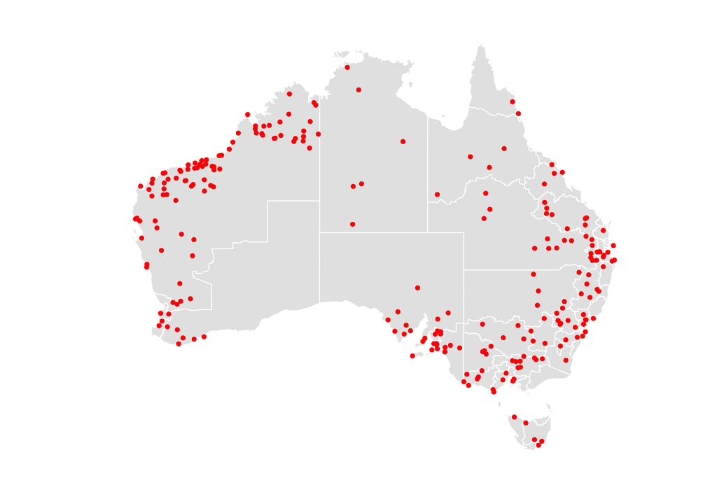

```r
library(tidyverse)
library(plotly)
load("data/oz_yr_prcp_50yrs.rda")
load("data/stns_oz.rda")
library(eechidna)
data(nat_map_2016)
library(ggthemes)
ggplot() +
  geom_polygon(data=nat_map_2016, mapping=aes(x=long, y=lat, group=group), fill="grey90", color="white") +
  theme_map() +
  geom_point(data=oz_yr_prcp_50yrs, aes(x=lon, y=lat), colour="red", size=2)
```

The Rmd file for the assignment has “scaffold” code to help you work your way through the questions. You will need to fill in the “??” with the necessary pieces to make it completely work for you.

# Grading

Points for the assignment will be based on:

- Whether the Rmd file, can take the data file as provided, and produce the results in the report
- Accuracy, clarity and readability of answers